# NYC Recycling Rates

Evelyn Cates

08/07/2019

## **Introduction**

When it comes to consumption and waste management we have a global problem that’s reaching a breaking point. Some countries have even stopped importing trash because they are unable to process the high quantities. My interest in recycling and curiosity has led me to perform an analysis of the waste management industry and look at another side of recycling not often analyzed to understand our current problem better.

#### **Problem**:

Consumers are strongly encouraged to recycle and use sustainable products; however, how is our waste management system handling the items that can be recycled and additional waste now that we have new additional electronic waste? How come our waste management systems are not building recycling dumpsters next to regular dumpsters? These questions led me to understand our current system by applying data science to answer questions and solve the problem of trash.

With the national recycling average of 34% as of 2015.[^1] I wanted to understand where our recycling problem lies, is it from the consumer or the waste management side. This analysis will provide insights into the areas of waste management we need to devote our efforts too.

Hypothesis: I think our current waste management system is not designed to keep up with the increased consumption and is not recycling at a rate of sustainability.

### Importing and Cleaning the Data

In conducting research, the Environmental Protection Agency had available data that allowed us to compare results from my analysis. I did not find a large amount of available open-source datasets since most companies do not share this information. I found the NYC Open Data source Recycling Diversion and Capture Rates. There are two areas from the dataset I wanted to focus on to solve this problem, the Diversion and Capture Rate which are defined as follows.

Diversion Rate: categorized as the percentage of total municipal solid waste collected by the Department of Sanitation that is disposed of by recycling.

Capture Rate: the percentage of total Paper or Metal/Glass/Plastic in the waste stream that is disposed of by recycling. Capture rate is the number of materials set out for residential recycling collection as a percentage of designated recyclable materials in both recycling and refuse streams. This ratio measures how much of the targeted materials are being recycled, which is a measure of how successfully such materials are recycled.

Once I imported the data, I used na.omit to remove any empty cells. Since we are currently finishing up the Fiscal Year 2019 and the dataset is not updated with the Fiscal Year 2020 I did not remove any incomplete date ranges. I also modified the name of the column to find them easier.

```r
knitr::opts_chunk$set(echo = TRUE)

recycling_df <- read.csv("Recycling_Diversion_and_Capture_Rates.csv", header = TRUE, sep = ",", stringsAsFactors = FALSE)

summary(recycling_df)
```

```
##      Zone             District         Fiscal.Month.Number  Fiscal.Year
##  Length:2832        Length:2832        Min.   : 1.00       Min.   :2016
##  Class :character   Class :character   1st Qu.: 3.75       1st Qu.:2017
##  Mode  :character   Mode  :character   Median : 6.50       Median :2018
##                                        Mean   : 6.50       Mean   :2018
##                                        3rd Qu.: 9.25       3rd Qu.:2018
##                                        Max.   :12.00       Max.   :2019
##   Month.Name        Diversion.Rate   Capture.Rate   Capture.Rate.1
##  Length:2832        Min.   : 5.90   Min.   :16.90   Min.   : 20.40
##  Class :character   1st Qu.:13.80   1st Qu.:31.90   1st Qu.: 48.40
##  Mode  :character   Median :16.90   Median :37.75   Median : 61.60
##                     Mean   :17.48   Mean   :38.43   Mean   : 61.22
##                     3rd Qu.:21.00   3rd Qu.:45.20   3rd Qu.: 74.42
##                     Max.   :33.80   Max.   :72.60   Max.   :101.80
##  Capture.Rate.2
##  Min.   :18.50
##  1st Qu.:39.70
##  Median :46.30
##  Mean   :46.16
##  3rd Qu.:52.62
##  Max.   :75.50
```

```r
#####Removing empty cells
recycling_df <- na.omit(recycling_df)
sum(is.na(recycling_df))
```

```
## [1] 0
```

```r
#Creating a new dataset without Fiscal Year 2020 dates
recycling_df2 <- subset(recycling_df, Fiscal.Year != 2020)

#####Using glimpse to review the new dataset
glimpse(recycling_df2)
```

```
## Observations: 2,832
## Variables: 9
## $ Zone                <chr> "Brooklyn North", "Brooklyn North", "Brookly…
## $ District            <chr> "BKN01", "BKN02", "BKN03", "BKN04", "BKN05",…
## $ Fiscal.Month.Number <int> 10, 10, 10, 10, 10, 10, 10, 10, 10, 10, 10, …
## $ Fiscal.Year         <int> 2019, 2019, 2019, 2019, 2019, 2019, 2019, 20…
## $ Month.Name          <chr> "April", "April", "April", "April", "April",…
## $ Diversion.Rate      <dbl> 14.7, 20.0, 12.2, 15.5, 10.1, 16.4, 14.0, 9.…
## $ Capture.Rate        <dbl> 44.9, 34.2, 33.5, 35.2, 22.3, 44.5, 34.0, 20…
## $ Capture.Rate.1      <dbl> 43.0, 57.9, 44.9, 68.5, 45.1, 59.4, 47.9, 35…
## $ Capture.Rate.2      <dbl> 44.1, 41.2, 38.2, 48.8, 31.5, 50.6, 39.2, 26…
```

### **Data Exploration**

After cleaning and organizing the dataset, I then moved on to understand the significance of the data and Diversion/ Capture rates. First, I plot a histogram of the Diversion Rate. By plotting the Diversion Rate I was able to visualize the overall data from 2016 - 2019.

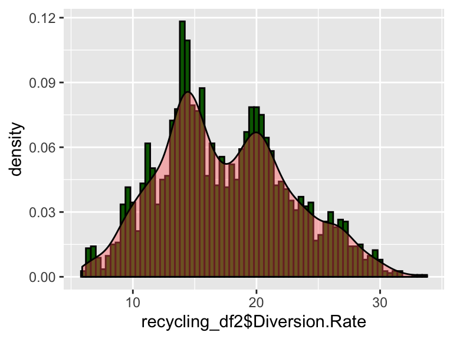

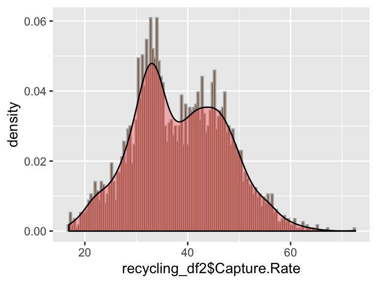

The next method of exploration and learning about the numbers was a monthly overview. For this, I made a boxplot where I saw the avg, upper quartile, lower quartile and the outliers. The exploration phase is important because you start asking more questions and start looking deeper into data.

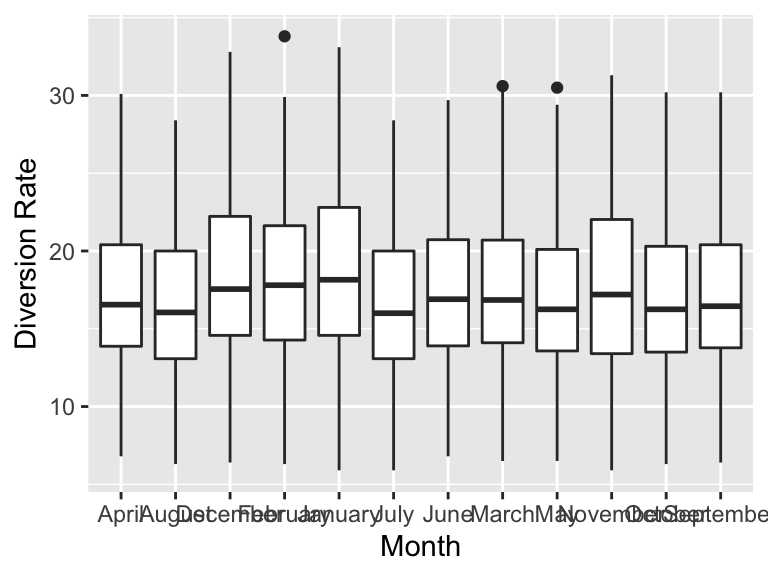

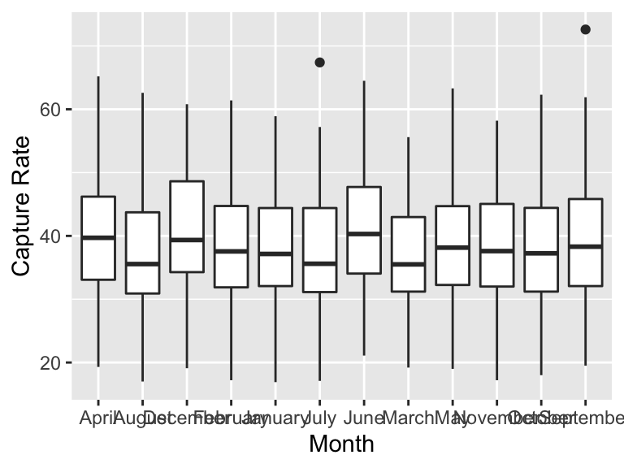

| Fiscal.Year | diversion_rate_fy |
| --- | --- |
| 2016 | 16.74393 |
| 2017 | 17.31992 |
| 2018 | 17.85169 |
| 2019 | 18.01963 |

| Fiscal.Year | capture_rate_fy |
| --- | --- |
| 2016 | 38.44901 |
| 2017 | 38.71285 |
| 2018 | 38.32768 |
| 2019 | 38.23121 |

```
##
## Call:
## lm(formula = Diversion.Rate ~ Fiscal.Year, data = recycling_df2)
##
## Residuals:
##     Min      1Q  Median      3Q     Max
## -11.338  -3.730  -0.530   3.462  16.970
##
## Coefficients:
##               Estimate Std. Error t value Pr(>|t|)
## (Intercept) -861.92394  177.77008  -4.849 1.31e-06 ***
## Fiscal.Year    0.43589    0.08811   4.947 7.98e-07 ***
## ---
## Signif. codes:  0 '***' 0.001 '**' 0.01 '*' 0.05 '.' 0.1 ' ' 1
##
## Residual standard error: 5.243 on 2830 degrees of freedom
## Multiple R-squared:  0.008573,   Adjusted R-squared:  0.008223
## F-statistic: 24.47 on 1 and 2830 DF,  p-value: 7.982e-07
```

### Analysis Insights

From this dataset I realize recycling goes beyond separating plastics, there are other factors to consider such as composting. During the exploratory data analysis, I made boxplots to understand where the number lies. This lead to more questions that allowed me to dig deeper.

Originally, I wanted to run a correlation analysis on the Zones and Capture Rates but a correlation test can only be completed with variables and the Zones are considered characters.I then used a regression analysis to look at the Diversion Rate per fiscal year.

The Capture Rate consisted YOY at 38% which is 4% higher than the national average. With 254 million tons of waste generated as of 2015 data, there is room for improvement in our current systems.[^2]

With over 62% of total Paper or Metal/Glass/Plastic in the waste stream is not disposed of by recycling. These numbers indicated we have to improve the way consumers recycling and how our waste management system works. My insight is that the way our current waste management system is designed is not set up for the amount of plastic we are consuming.

This form of study can be applied to other areas were looking at a dataset and measuring effectiveness is necessary.

## **Conclusion**

This analysis taught me how to pull data and gain meaningful insights along with running a regression analysis. This report only scratches the surface of our waste management system and I would like to continue to expand on it. The top three insights were:

1. Capture Rate is stagnant and is only 4% higher than the national average. The data shows changes are not happening in our waste management system. Looking at the whole country, what are the factors that need to be analyzed to better understand the problem?
2. Recycling and waste management are co-dependent. In order to improve recycling, we most reduce our single use plastic and our waste management system has to change with our lifestyle now.
3. This form of analysis goes beyond recycling and can be used to partner with other industries or departments to expand our knowledge of what we know and gain more out of the data.

To tackle this complex industry we must be able to understand it and this dataset allows my first glimpse into how I can apply data and specifically R to learn how to start solving our global waste problem.

Sources:

[^1]: https://archive.epa.gov/epawaste/nonhaz/municipal/web/html/
[^2]: https://www.recyclingtoday.com/article/2015-us-recycling-rate-epa/